# CC_Module2

### Paso 5: The third variable as a shape

Podemos introducir una tercera variable a nuestro scatter plot. Los automóviles pueden categorizarse por el número de cilidros, así que vamos a usar cada punto para representar eso.

#### 5.1. Creamos un factor para la variable cylinder

```r
mtcars$cylFactor <- factor(mtcars$cyl)
```

#### 5.2. Realizamos el gráfico

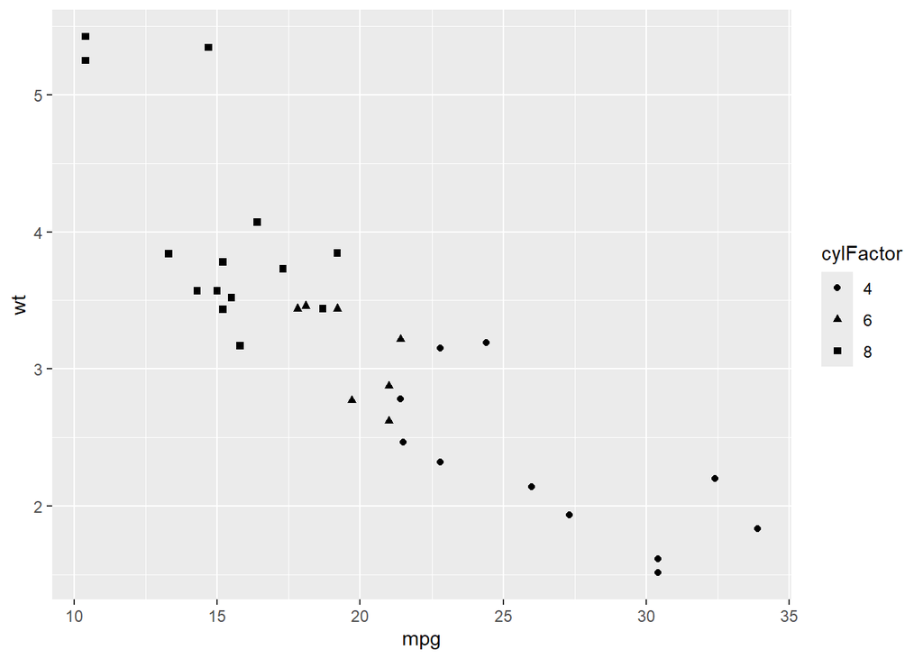

```r
ggplot(mtcars, aes(x=mpg,y=wt, shape = cylFactor)) + geom_point()
```

### Paso 6: Colour

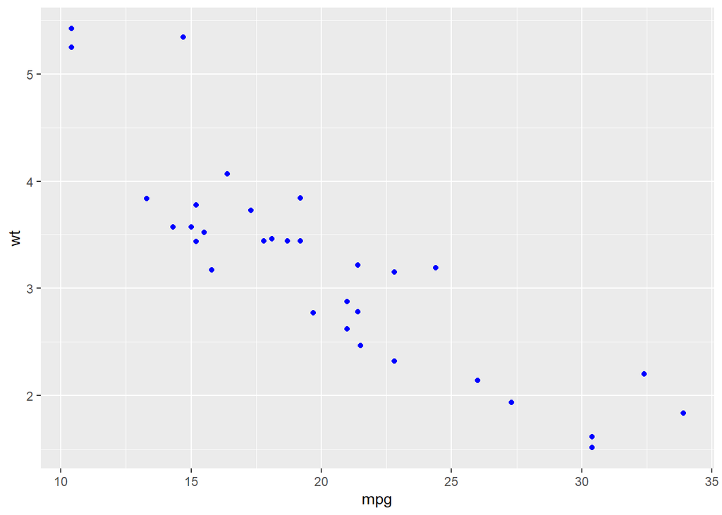

```r
ggplot(mtcars, aes ( x = mpg, y = wt)) + geom_point(shape=19, colour="blue")
```

### Paso 7: The third variable as a color

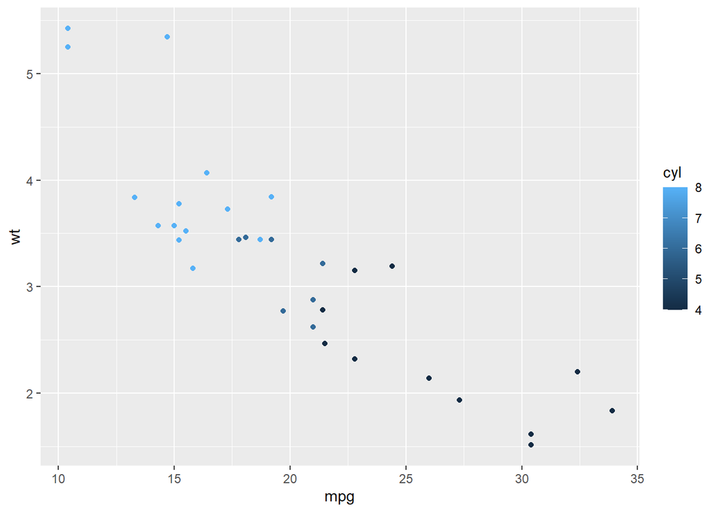

```r
ggplot(mtcars, aes(x=mpg,y=wt, color = cyl)) + geom_point(shape=19)
```

Pero, como mencionamos antes, **la variable “cylynder” la entendemos más como factor:**

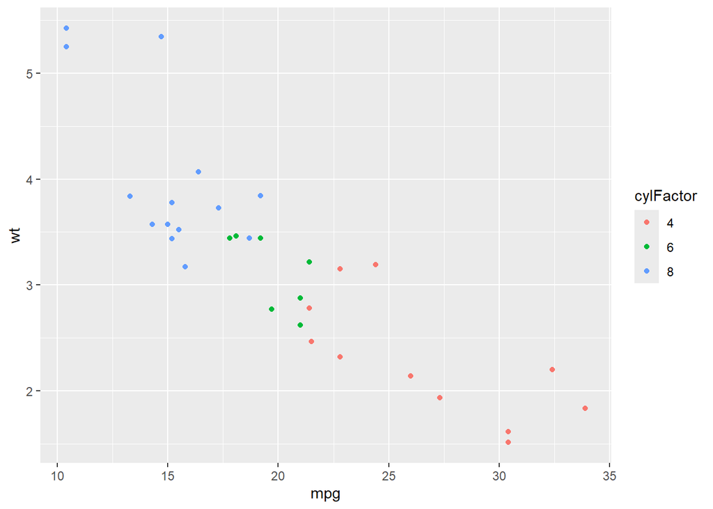

```r
ggplot(mtcars, aes(x=mpg,y=wt,color = cylFactor)) + geom_point(shape=19)
```

### Paso 8: Labels

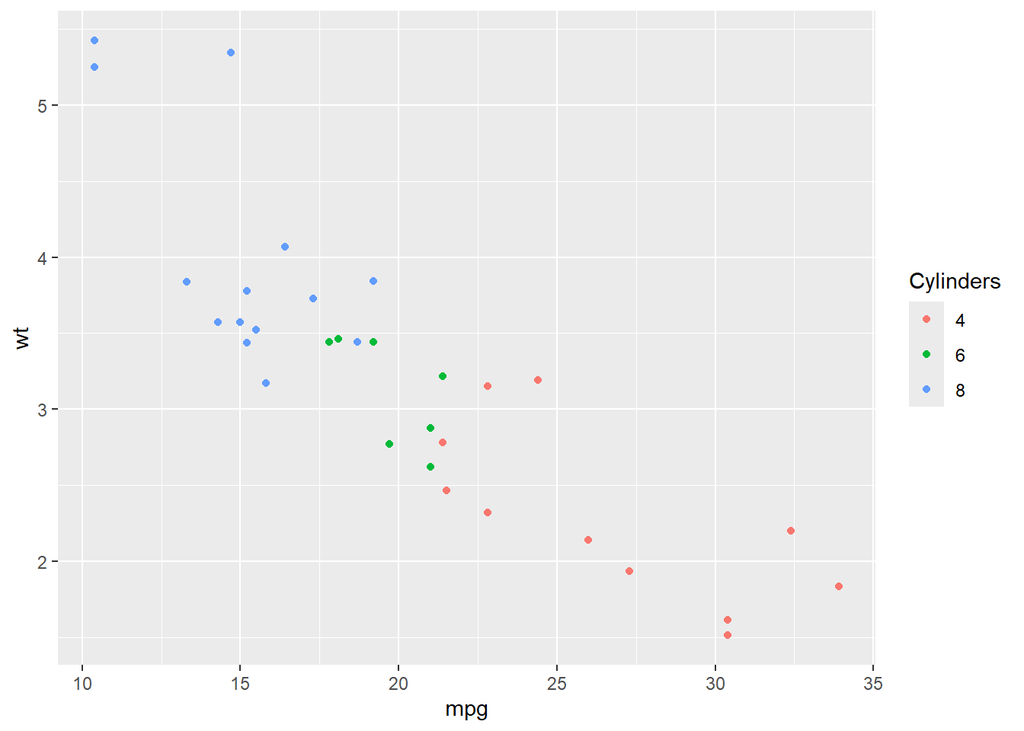

```r
ggplot(mtcars, aes(x=mpg,y=wt,color = cylFactor)) + geom_point(shape=19) + labs(colour = "Cylinders")
```

### Paso 9: Title

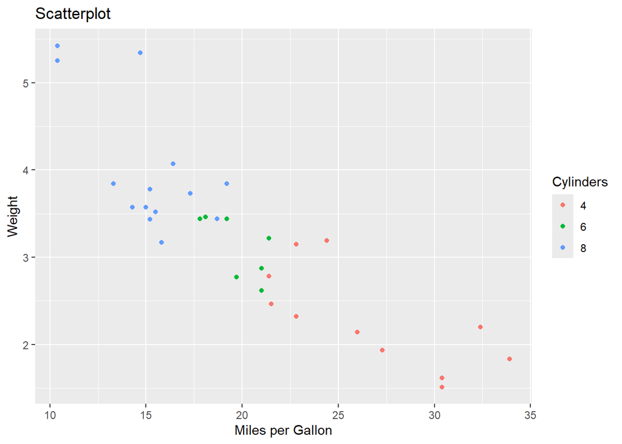

```r
ggplot(mtcars, aes(x=mpg,y=wt,color = cylFactor)) + geom_point(shape=19) +
  xlab("Miles per Gallon") +
  ylab("Weight") +
  labs(colour = "Cylinders") +
  ggtitle("Scatterplot")
```

## Lines Plots and Regression

Vamos a ver Regresión Lineal y Regresión Gausseana

#### Introducción de base de datos `EuStockMarkets`

Este dataset contiene data historial de índices de mercados en Europa

```r
EuStockDF <- as.data.frame(EuStockMarkets)
```

Vemos nuestra data

```r
head(EuStockDF)
```

```
      DAX    SMI    CAC   FTSE
1 1628.75 1678.1 1772.8 2443.6
2 1613.63 1688.5 1750.5 2460.2
3 1606.51 1678.6 1718.0 2448.2
4 1621.04 1684.1 1708.1 2470.4
5 1618.16 1686.6 1723.1 2484.7
6 1610.61 1671.6 1714.3 2466.8
```

### Simple Line Plot

Trabajamos primero con la columna `DAX.`

- Our **X axis** will simply display the current row number
- Our **Y axis** will display the DAX data

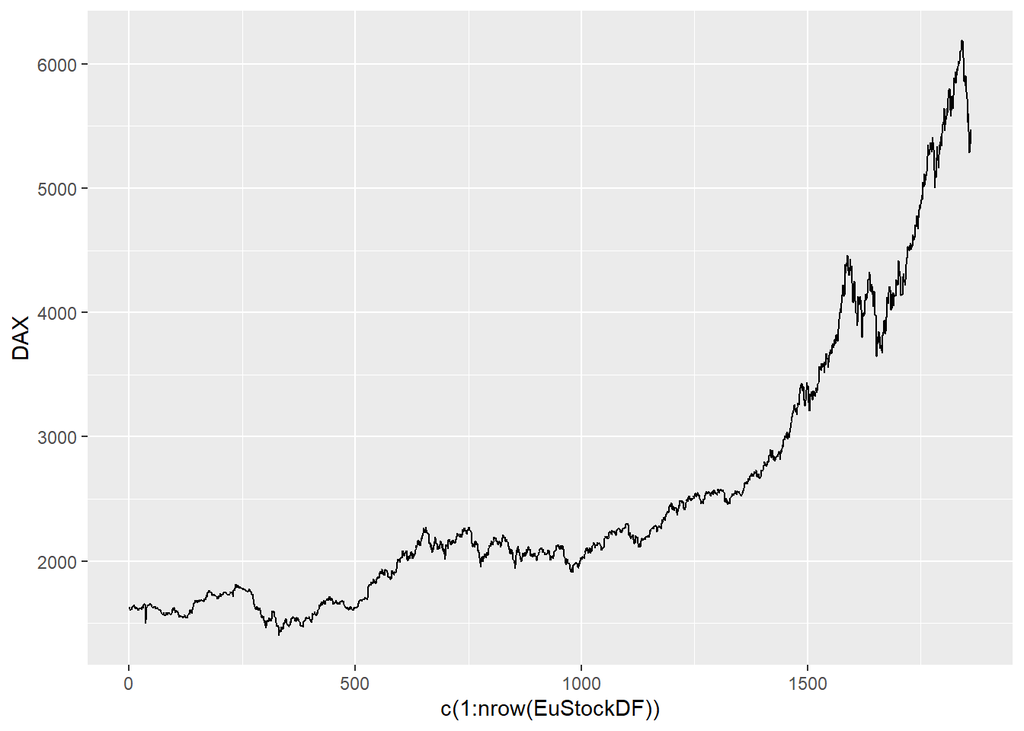

```r
ggplot(EuStockDF, aes(x=c(1:nrow(EuStockDF)), y = DAX)) + geom_line()
```

#### Paso 1: Line boldness

- si queremos modificar el grosor

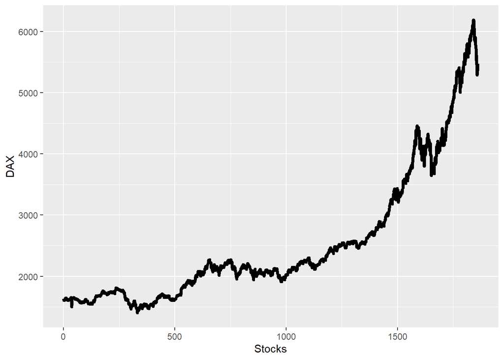

```r
ggplot(EuStockDF, aes(x=c(1:nrow(EuStockDF)), y = DAX)) +
  geom_line(size = 1.5) +
  labs(x = "Stocks")
```

#### Paso 2: Add color

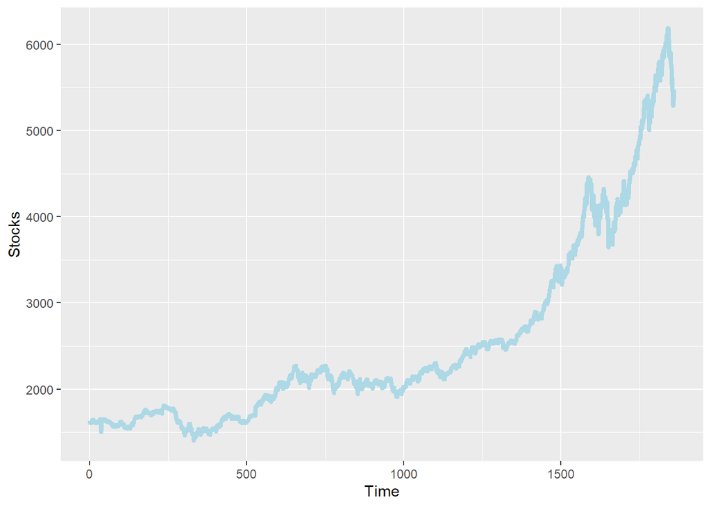

```r
ggplot(EuStockDF, aes(x=c(1:nrow(EuStockDF)), y = DAX)) +
  geom_line(size = 1.5, colour="light blue") +
  labs(x = "Time", y = "Stocks")
```

### Multiple line plots

```r
#install.packages("dplyr")
library(dplyr)
```

```r
head(EuStockDF)
```

```
      DAX    SMI    CAC   FTSE
1 1628.75 1678.1 1772.8 2443.6
2 1613.63 1688.5 1750.5 2460.2
3 1606.51 1678.6 1718.0 2448.2
4 1621.04 1684.1 1708.1 2470.4
5 1618.16 1686.6 1723.1 2484.7
6 1610.61 1671.6 1714.3 2466.8
```

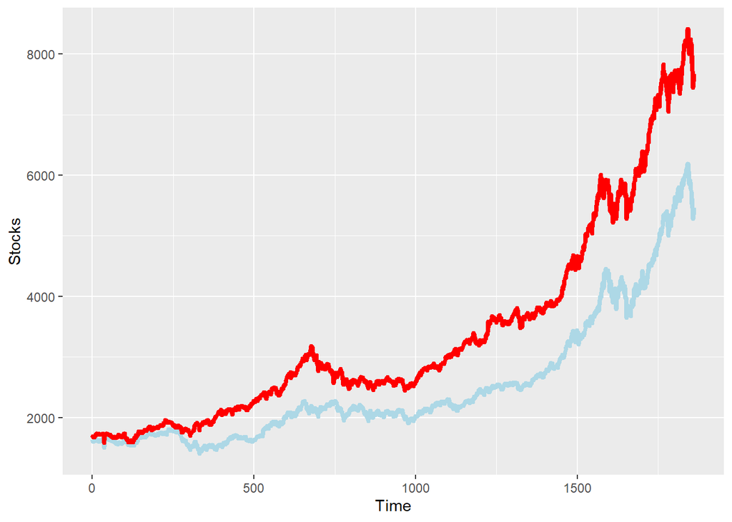

```r
dax_smi_plot <- ggplot() +
  geom_line(data = EuStockDF, aes(x=c(1:nrow(EuStockDF)), y = DAX), size = 1.5, colour = "light blue") +
  geom_line(data = EuStockDF, aes(x=c(1:nrow(EuStockDF)), y = SMI), size = 1.5, colour = "red") + labs(x = "Time", y = "Stocks")

print(dax_smi_plot)
```

#### **Utilizamos las 4 variables:**

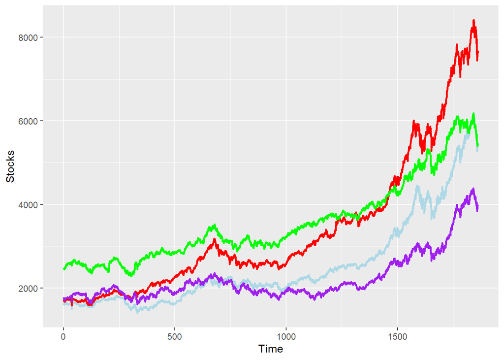

```r
all_stocks <- ggplot() +
  geom_line(data = EuStockDF, aes(x=c(1:nrow(EuStockDF)), y = DAX), size = 1, colour = "light blue") +
  geom_line(data = EuStockDF, aes(x=c(1:nrow(EuStockDF)), y = SMI), size = 1, colour = "red") +
  geom_line(data = EuStockDF, aes(x=c(1:nrow(EuStockDF)), y = CAC), size = 1, colour = "purple")+
  geom_line(data = EuStockDF, aes(x=c(1:nrow(EuStockDF)), y = FTSE), size = 1, colour = "green") +
  labs( x = "Time", y = "Stocks")


print(all_stocks)
```

#### Agregamos las etiquetas

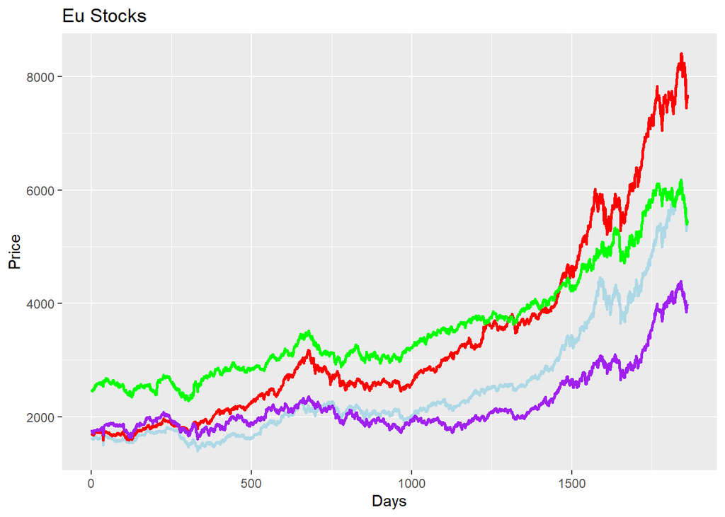

```r
legend_stocks <- all_stocks + xlab("Days") + ylab("Price") + ggtitle("Eu Stocks")

print(legend_stocks)
```

### Linear Regression

- En este caso nosotros **estamos ploteando “miles per gallon” ~ “weight”**
- `metohd="lm"` –> lineal model

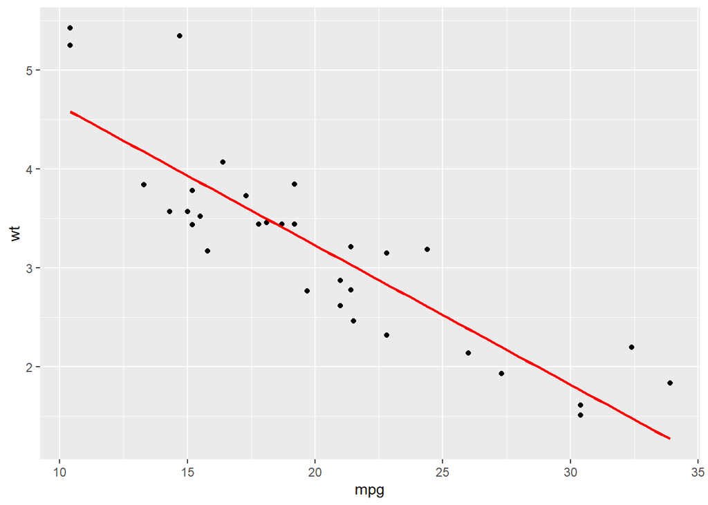

```r
ggplot(mtcars, aes(x=mpg,y=wt)) + geom_point(shape=19) + geom_smooth(method="lm", se= FALSE, color = "red")
```

#### Paso 2: Confidence interval

- **Recordar el cylFactor** de la primera parte del documento
- **The confidence interval (se=TRUE)** is constructed so that the model is 95% certain that a data point would fall inside the bands.

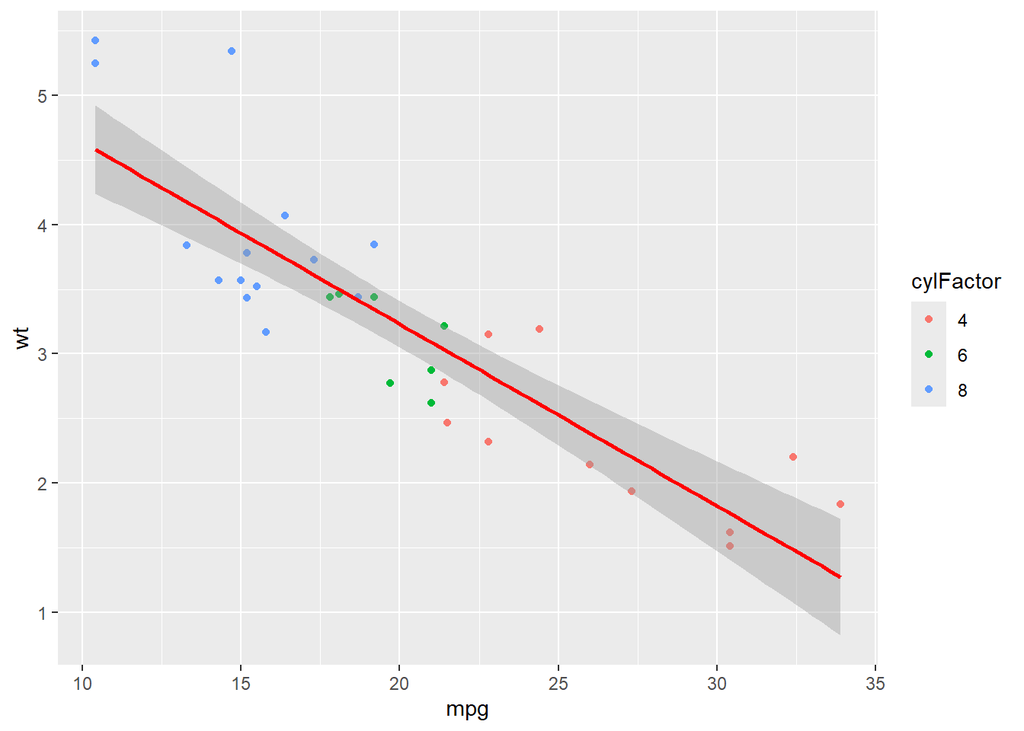

```r
#se = TRUE -> confidence interval appear (default = true)
ggplot(mtcars,aes(x=mpg,y=wt, color = cylFactor)) + geom_point(shape=19) + geom_smooth(method="lm", se= TRUE, color= "red")
```

#### Paso 3: Labels

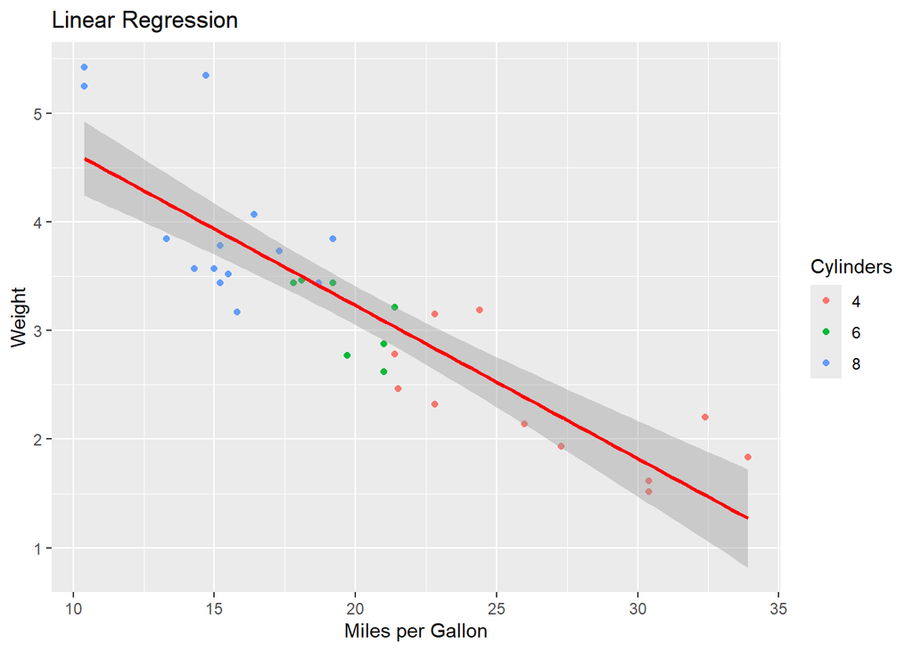

```r
ggplot(mtcars,aes(x=mpg,y=wt, color = cylFactor)) + geom_point(shape=19) + geom_smooth(method="lm", se= TRUE, color= "red") + xlab("Miles per Gallon") + ylab("Weight") + labs(colour= "Cylinders") + ggtitle("Linear Regression")
```

### Gaussian Regression

- To use this type of model, you simply need to pass the “auto” parameter to the “method” atrribute

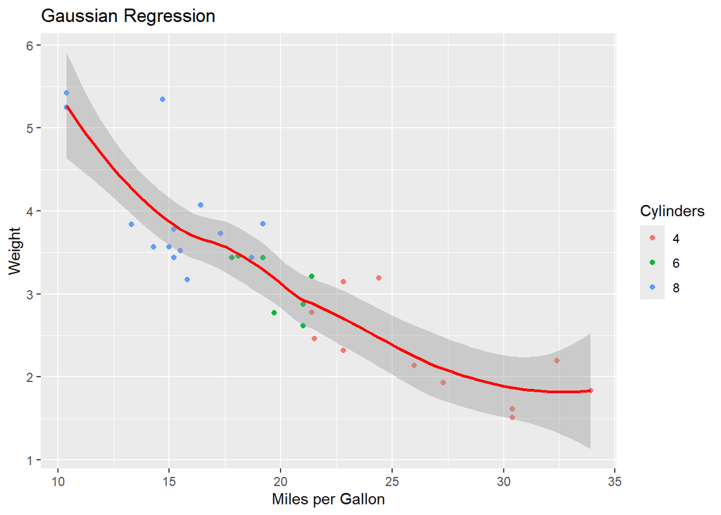

```r
ggplot(mtcars,aes(x=mpg,y=wt,color= cylFactor)) +
  geom_point(shape=19) +
  geom_smooth(method="auto", se= TRUE, color = "red")+
  xlab("Miles per Gallon") +
  ylab("Weight") +
  labs(colour= "Cylinders") +
  ggtitle("Gaussian Regression")
```